# EDA Diamonds 2

Francia Moscoso

March 12, 2016

setwd(“~/SprintboardProject”)

**Loading Libraries and ‘diamonds’ data set**

```r
library(ggplot2)
library(gridExtra)
library(dplyr)
```

To silence the execution of the library function eg.library(dplyr), use statement: {r message=F, warning=F}

```r
data("diamonds")
str(diamonds)
```

```
Classes 'tbl_df', 'tbl' and 'data.frame':   53940 obs. of  10 variables:
 $ carat  : num  0.23 0.21 0.23 0.29 0.31 0.24 0.24 0.26 0.22 0.23 ...
 $ cut    : Ord.factor w/ 5 levels "Fair"<"Good"<..: 5 4 2 4 2 3 3 3 1 3 ...
 $ color  : Ord.factor w/ 7 levels "D"<"E"<"F"<"G"<..: 2 2 2 6 7 7 6 5 2 5 ...
 $ clarity: Ord.factor w/ 8 levels "I1"<"SI2"<"SI1"<..: 2 3 5 4 2 6 7 3 4 5 ...
 $ depth  : num  61.5 59.8 56.9 62.4 63.3 62.8 62.3 61.9 65.1 59.4 ...
 $ table  : num  55 61 65 58 58 57 57 55 61 61 ...
 $ price  : int  326 326 327 334 335 336 336 337 337 338 ...
 $ x      : num  3.95 3.89 4.05 4.2 4.34 3.94 3.95 4.07 3.87 4 ...
 $ y      : num  3.98 3.84 4.07 4.23 4.35 3.96 3.98 4.11 3.78 4.05 ...
 $ z      : num  2.43 2.31 2.31 2.63 2.75 2.48 2.47 2.53 2.49 2.39 ...
```

**Create a scatterplot of price vs x using ggplot syntax.**

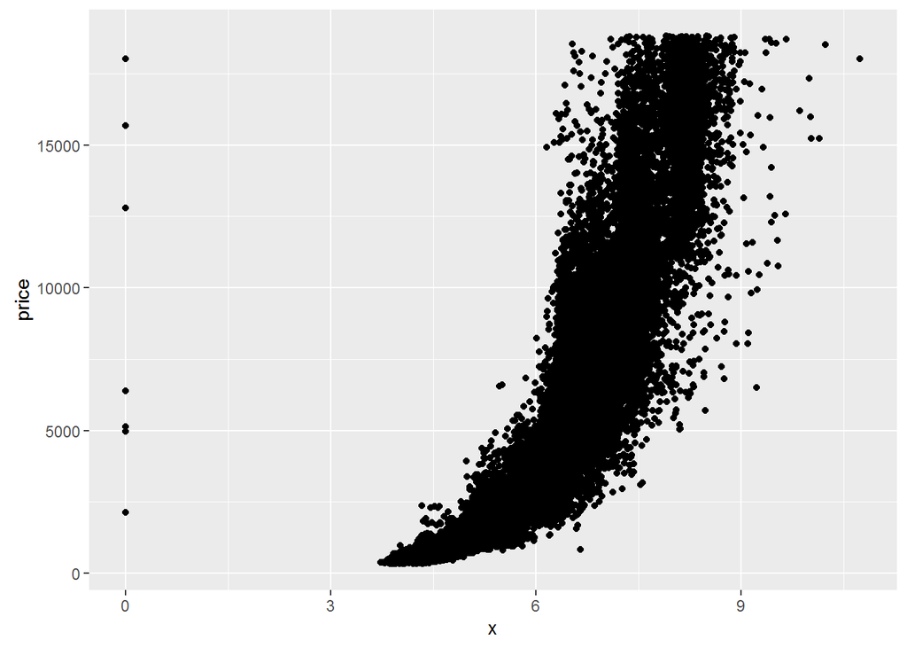

```r
ggplot(aes(x=x, y=price), data=diamonds) +
      geom_point()
```

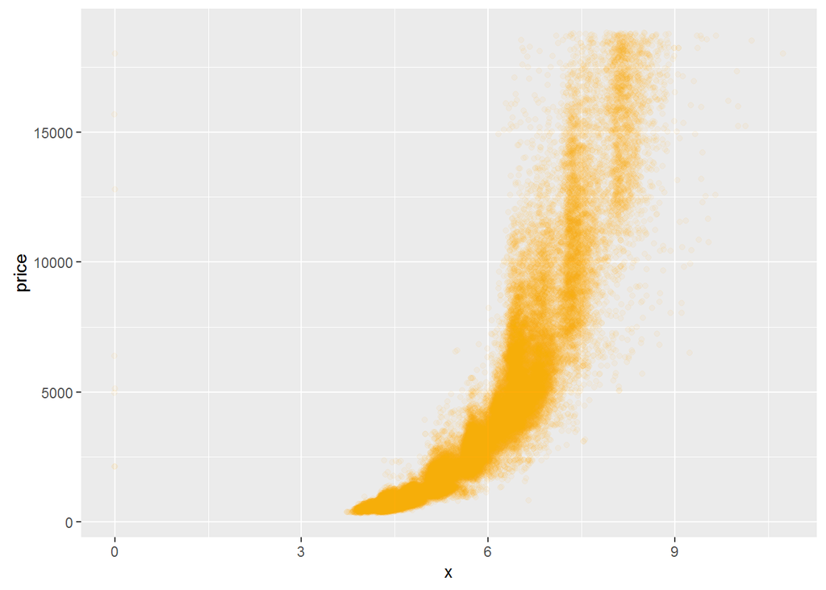

```r
ggplot(aes(x=x, y=price), data=diamonds) +
      geom_point(alpha=1/20, position = position_jitter(h=0), color = 'orange')
```

**What are the observations about the scatterplot of price vs. x?**  
There is an exponential relationship between price and x. Greater activity in x-axis starting from 4 to 7. Price with values less than 7,500 has a greater activity for x between 4 and 7. Price with values more than 7,500 has an activity for x between 7 and 9.

```r
range(diamonds$x)
```

```
## [1]  0.00 10.74
```

**What is the correlation between price and y?**

```r
cor.test(diamonds$price, diamonds$y, method = "pearson")
```

```
##
##  Pearson's product-moment correlation
##
## data:  diamonds$price and diamonds$y
## t = 401.14, df = 53938, p-value < 2.2e-16
## alternative hypothesis: true correlation is not equal to 0
## 95 percent confidence interval:
##  0.8632867 0.8675241
## sample estimates:
##       cor
## 0.8654209
```

**What is the correlation between price and z?**

```r
cor.test(diamonds$price, diamonds$z, method = "pearson")
```

```
##
##  Pearson's product-moment correlation
##
## data:  diamonds$price and diamonds$z
## t = 393.6, df = 53938, p-value < 2.2e-16
## alternative hypothesis: true correlation is not equal to 0
## 95 percent confidence interval:
##  0.8590541 0.8634131
## sample estimates:
##       cor
## 0.8612494
```

**Create a simple scatter plot of price vs depth.**

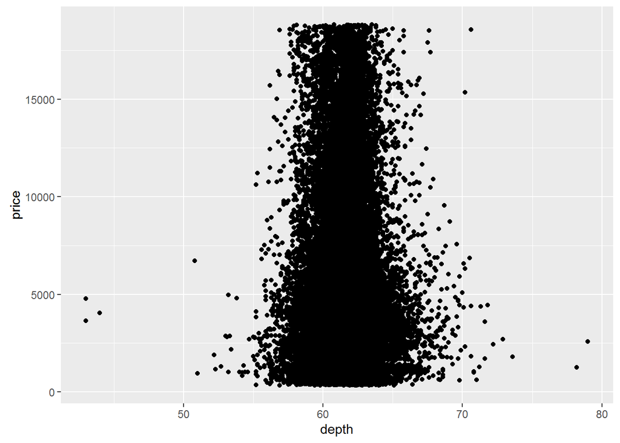

```r
ggplot(aes(x=depth, y=price), data=diamonds) + geom_point()
```

**Change the code to make the transparency of the points to be 1/100 of what they are now and mark the x-axis every 2 units.**

```r
range(diamonds$depth)
```

```
## [1] 43 79
```

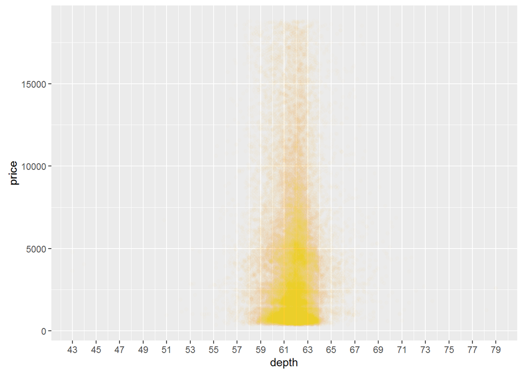

```r
ggplot(data=diamonds, aes(x=depth, y=price)) +
      geom_point(alpha=1/100,
                 color ='orange') +
                 scale_x_continuous(breaks = seq(43,79,2))
```

**Note**: if in the graphic above we use scale_x_discrete(breaks = seq(43,79,2)) the graphs will Starts from 0 and leave an empty space before 43

**Based on the scatterplot of depth vs. price, most diamonds are between what values of depth?**  
60 to 63

**What is the correlation of depth vs. price? Based on the correlation coefficient would you use depth to predict the price of a diamond?**  
The correlation -0.01 is too week to predict the price of a diamond.

```r
cor.test(diamonds$depth, diamonds$price, method = "pearson")
```

```
##
##  Pearson's product-moment correlation
##
## data:  diamonds$depth and diamonds$price
## t = -2.473, df = 53938, p-value = 0.0134
## alternative hypothesis: true correlation is not equal to 0
## 95 percent confidence interval:
##  -0.019084756 -0.002208537
## sample estimates:
##        cor
## -0.0106474
```

```r
range(diamonds$price)
```

```
## [1]   326 18823
```

```r
range(diamonds$carat)
```

```
## [1] 0.20 5.01
```

```r
range(diamonds$carat)
```

```
## [1] 0.20 5.01
```

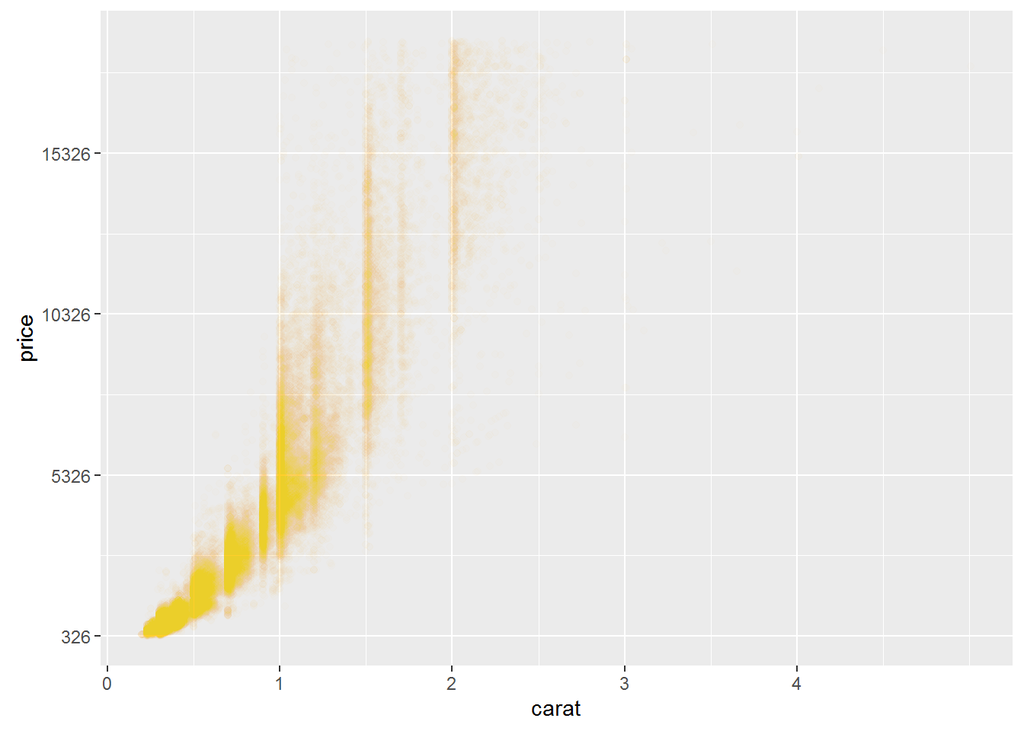

```r
ggplot(data=diamonds, aes(x=carat, y=price)) +
      geom_point(alpha=1/100,
                 color ='orange') +
                 scale_x_continuous(breaks = seq(0,(5-5*0.01),1)) +
                 scale_y_continuous(breaks = seq(326,(18823-18823*0.01),5000))
```

**Create a scatterplot of price vs. volume (x*y*z). This is a very rough approximation for a dismonds’s volume. Create a new variable for volumn in the diamonds data frame. This will be useful in a later exercise.**

```r
diamonds$volume <- diamonds$x*diamonds$y*diamonds$z
range(diamonds$volume)
```

```
## [1]    0.000 3840.598
```

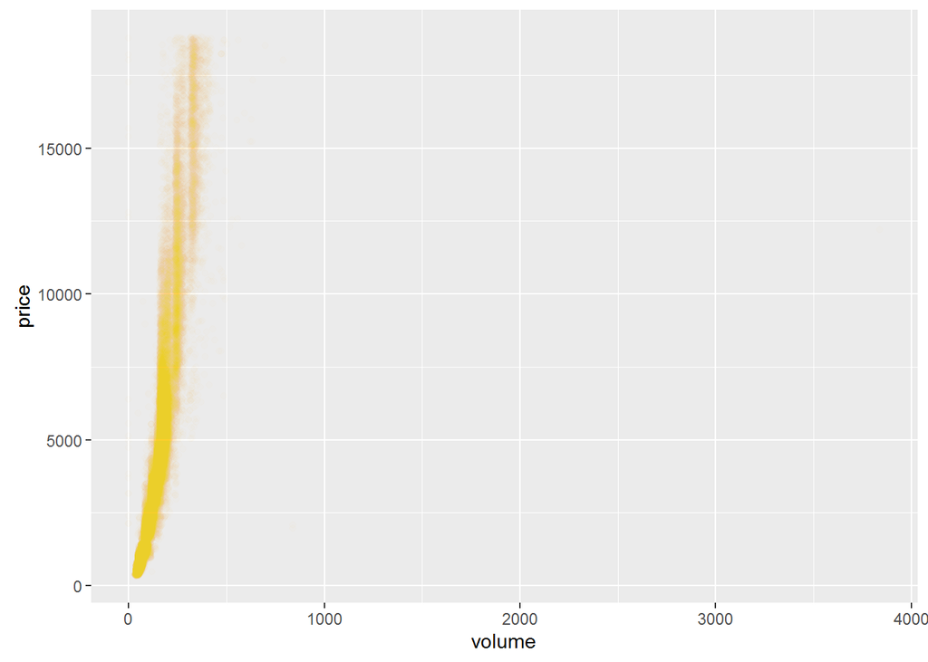

```r
ggplot(data=diamonds, aes(x=volume, y=price)) +
      geom_point(alpha=1/100,
                 color ='orange')
```

**What are your observations from the price vs. volume scatterplot?** Some volumes are zero. There is an expensive diamond with price close to 4,000. There is not significant activity in a volume greater than 400. Most of the prices are below 10,000.

You can find out how many diamonds have 0 volume by using count(diamonds$volume == 0). The count function comes with the plyr package. **Note**: If you ran the count function from plyr, you need to unload the plyr package detach(“package:plyr”, unload=TRUE) The plyr will conflict with the dplyr package in later esxercises.

- It does not work: count(diamonds$volume == 0) It gives error: Error in UseMethod(“group_by_”) : no applicable method for ‘group_by_’ applied to an object of class “logical”
- It does not work: detach(“package:plyr”, unload=TRUE) gives error: Error in detach(“package:plyr”, unload = TRUE) : invalid ‘name’ argument

**What is the correlation of price and volume? Exclude diamonds that have a volume of 0 or that are greater than or equal to 800?**

```r
with(subset(diamonds,volume != 0 & volume<800), cor.test(volume,price, method = "pearson"))
```

```
##
##  Pearson's product-moment correlation
##
## data:  volume and price
## t = 559.19, df = 53915, p-value < 2.2e-16
## alternative hypothesis: true correlation is not equal to 0
## 95 percent confidence interval:
##  0.9222944 0.9247772
## sample estimates:
##       cor
## 0.9235455
```

**Subset the data to exclude diamonds with a volume greater than or equal to 800. Also, exclude diamonds with a volume of 0. Adjust the transparency of the points and add a linear model to the plot. Do you think this would be a useful model to estimate of price of diamonds? Why or why not?** A 0.92 correlation is very strong which is not a good thing. The correlation was an artifact of the nature of the variable. One was really a super set of the other (see plots below).

**Create subset that exclude diamonds with a volume greater than or equal to 800.**

```r
diamondsNewSubset = subset(diamonds,volume != 0 & volume<800)
```

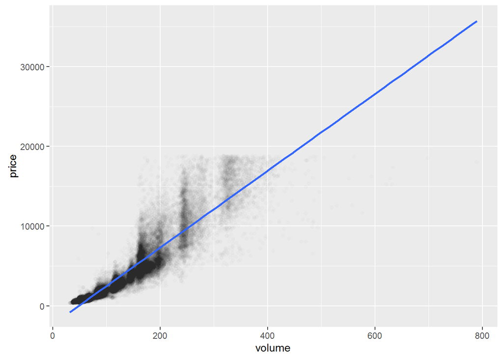

```r
ggplot(data=diamondsNewSubset, aes(x=volume, y=price)) +
      geom_point(alpha=1/100) +
      geom_smooth(method = "lm")
```

Reducing x-axis from 0 to 400. However, there is an empty space after the 400 volume.The next plot will display limits much better by using x_lim.

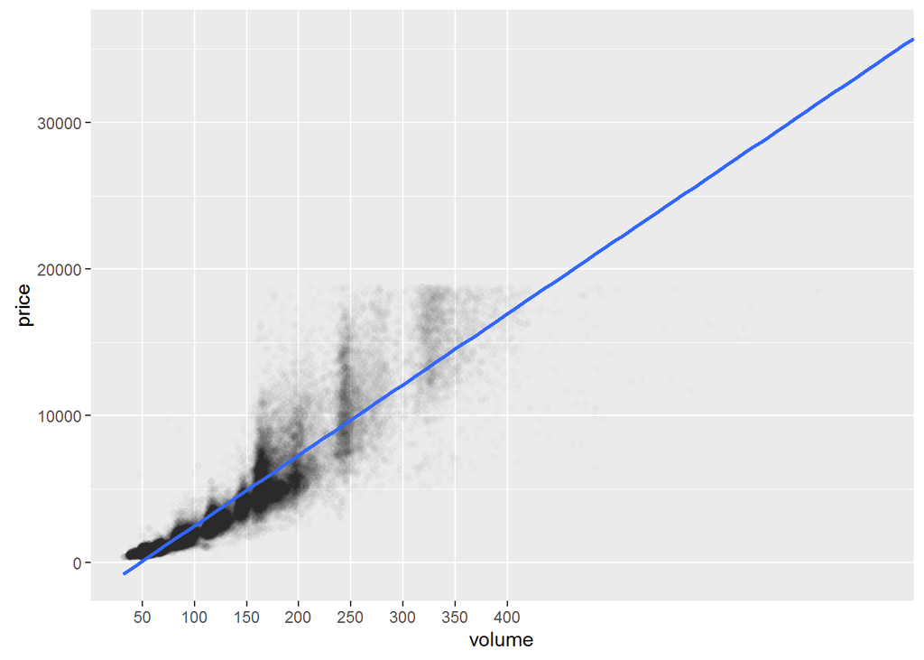

```r
ggplot(data=diamondsNewSubset, aes(x=volume, y=price)) +
      geom_point(alpha=1/100) +
      scale_x_discrete(breaks = seq(0,400,50)) +
      geom_smooth(method = "lm")
```

The following graphic shows better the x-axis than the one above. Look how we replace xlim for scale_x_discrete.

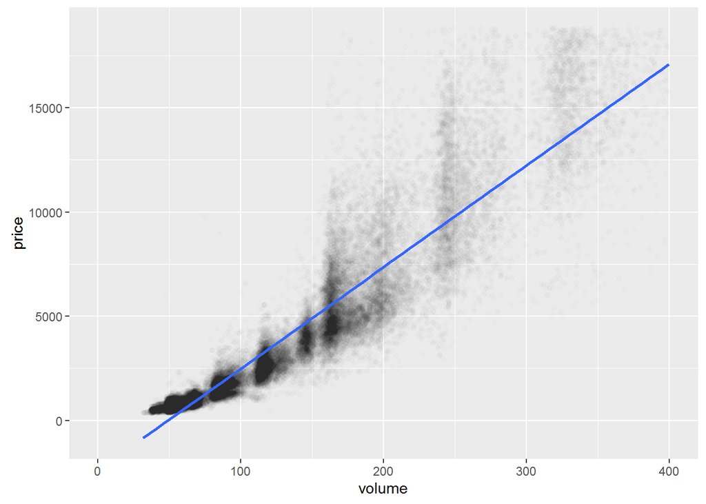

```r
ggplot(data=diamondsNewSubset, aes(x=volume, y=price)) +
      geom_point(alpha=1/100) +
      xlim(0,400) +
      #scale_x_discrete(breaks = seq(0,400,50)) +
      geom_smooth(method = "lm")
```

**Use the function dplyr package to create a new data frame containing info on diamonds by clarity.**  
Name the data frame diamondsByClarity The data frame should contain the following: (1) mean_price (2) median_price (3) min_price (4) max_price (5) n, where n is the number of diamonds in each level of clarity.

```r
diamonds_By_Clarity <- group_by(diamonds, clarity)
calc_diamonds_By_clarity <- summarise(diamonds_By_Clarity,
        mean_price = mean(price),
        median_price = median(price),
        min_price = min(price),
        n = n())
calc_diamonds_By_clarity
```

```
## Source: local data frame [8 x 5]
##
##   clarity mean_price median_price min_price     n
##    (fctr)      (dbl)        (dbl)     (int) (int)
## 1      I1   3924.169         3344       345   741
## 2     SI2   5063.029         4072       326  9194
## 3     SI1   3996.001         2822       326 13065
## 4     VS2   3924.989         2054       334 12258
## 5     VS1   3839.455         2005       327  8171
## 6    VVS2   3283.737         1311       336  5066
## 7    VVS1   2523.115         1093       336  3655
## 8      IF   2864.839         1080       369  1790
```

**We have created summary data frames with the mean price by clarity and color. You can run the code in R to verify what data is in the variables diamonds_mp_by_clarity and diamonds_mp_by_color. Your task is to write additional code to create two bar plots on one output image using the grid.arrange function from the package gridExtra.**  
Be sure you have installed and loaded the gridExtra package.

```r
diamonds_by_clarity <- group_by(diamonds, clarity)
diamonds_mp_by_clarity <- summarise(diamonds_by_clarity, mean_price = mean(price))
diamonds_mp_by_clarity
```

```
## Source: local data frame [8 x 2]
##
##   clarity mean_price
##    (fctr)      (dbl)
## 1      I1   3924.169
## 2     SI2   5063.029
## 3     SI1   3996.001
## 4     VS2   3924.989
## 5     VS1   3839.455
## 6    VVS2   3283.737
## 7    VVS1   2523.115
## 8      IF   2864.839
```

```r
diamonds_by_color <- group_by(diamonds, color)
diamonds_mp_by_color <- summarise(diamonds_by_color, mean_price = mean(price))
diamonds_mp_by_color
```

```
## Source: local data frame [7 x 2]
##
##    color mean_price
##   (fctr)      (dbl)
## 1      D   3169.954
## 2      E   3076.752
## 3      F   3724.886
## 4      G   3999.136
## 5      H   4486.669
## 6      I   5091.875
## 7      J   5323.818
```

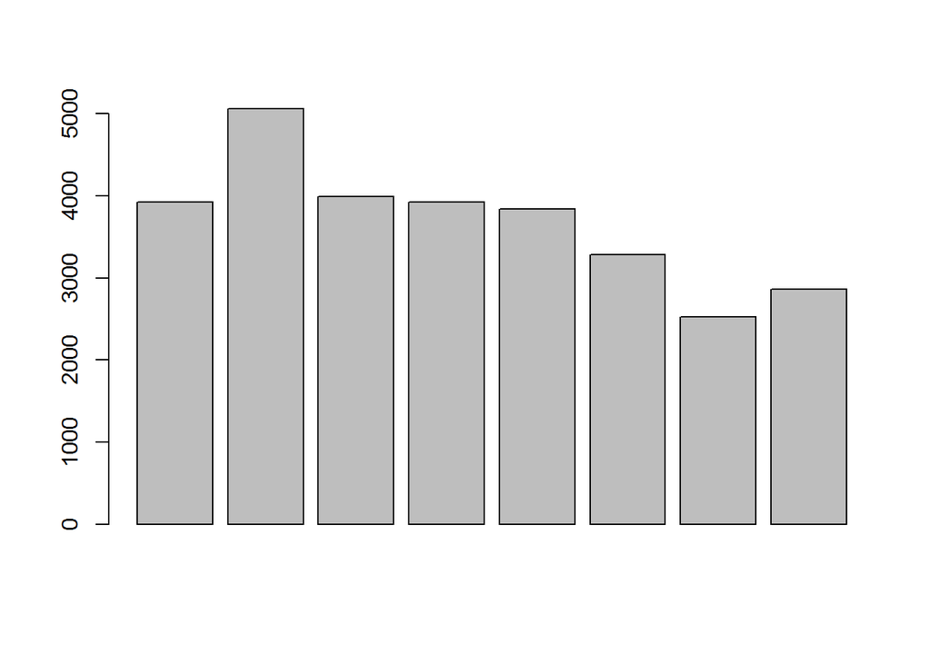

```r
p1 <- barplot(diamonds_mp_by_clarity$mean_price)
```

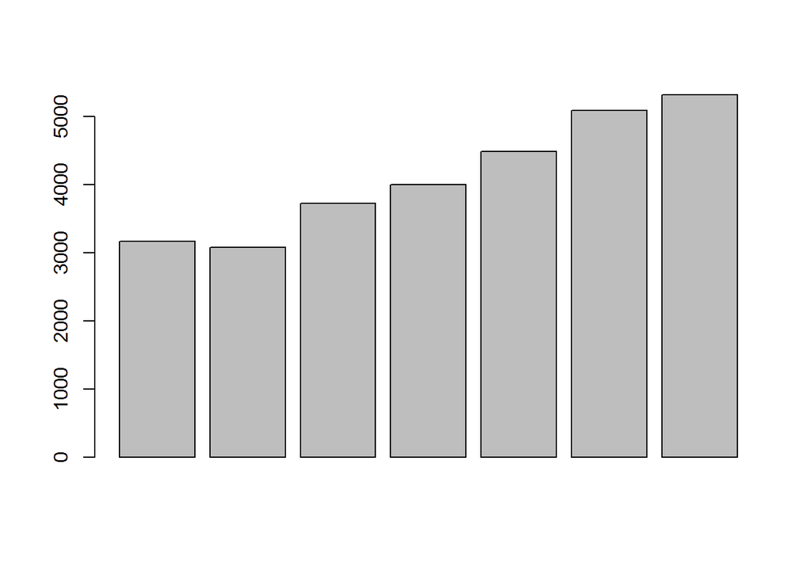

```r
p2 <- barplot(diamonds_mp_by_color$mean_price)
```

The grid.arrange function gives error: Error in gList…

```r
#grid.arrange(p1,p2,ncol=2)
```

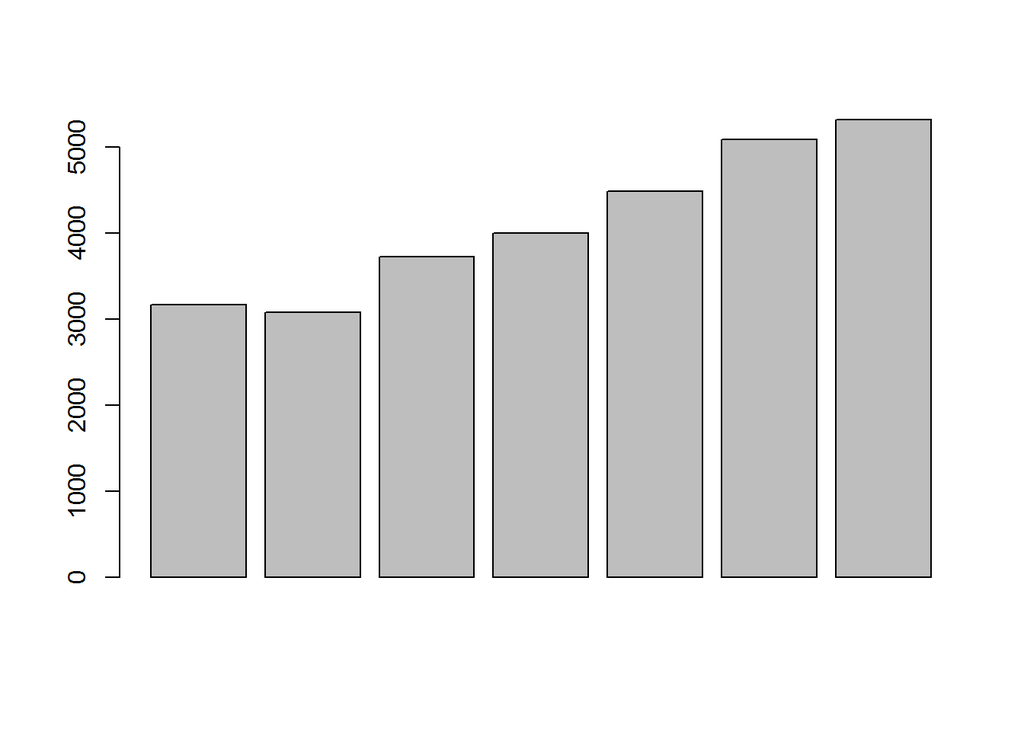

```r
diamonds_by_color <- group_by(diamonds, color)
diamonds_mp_by_color <- summarise(diamonds_by_color, mean_price = mean(price))
p3 <- barplot(diamonds_mp_by_color$mean_price)
```